# Practical_Machine_Learning

This is my report for the course project for the Coursera course “Practical Machine Learning”.

```r
## These are the libraries required for the program to work
library(caret)
library(randomForest)
```

```r
library(e1071)
library(rpart)
library(rpart.plot)
```

I first ensure that the requisite files are downloaded, if they are not; I then open them for processing.

```r
## The URLs for the training and test data sets
urlTrain <- "https://d396qusza40orc.cloudfront.net/predmachlearn/pml-training.csv"
urlTest <- "https://d396qusza40orc.cloudfront.net/predmachlearn/pml-testing.csv"
fTrain <- "pml-training.csv"

## Checking to see if the file is already downloaded or not, and then opening it
if (file.exists(fTrain)) {
        TrainD <- read.csv(fTrain, na.strings=c("NA","#DIV/0!",""))
} else {
        download.file(urlTrain,fTrain,method="curl")
        TrainD <- read.csv(fTrain, na.strings=c("NA","#DIV/0!",""))
        }

fTest <-  "pml-testing.csv"

if (file.exists(fTest)) {
        TestD <- read.csv(fTest, na.strings=c("NA","#DIV/0!",""))
} else {
        download.file(urlTest,fTest,method="curl")
        TestD <- read.csv(fTest, na.strings=c("NA","#DIV/0!",""))
}

## The training and test data sets are now in TrainD and TestD, respectively.
```

I now set up for the cross-validation step. I take the training data set and divide it into training and test subsets (using a ratio of 60:40 for train:test).

```r
inTrain <- createDataPartition(y = TrainD$classe, list = FALSE, p=0.6)
trainData <- TrainD[inTrain,]
testData <- TrainD[-inTrain,]
dim(trainData)
```

```
## [1] 11776   160
```

```r
dim(testData)
```

```
## [1] 7846  160
```

I now examine the data set to identify the potential predictor variables. To do this, I first eliminate variables that won’t be as useful; for example, those that contain many NA values.

```r
table(is.na(trainData))
```

```
##
##   FALSE    TRUE
##  730172 1153988
```

I now identify the variables that are mostly NA and remove those columns that have a lot of NA values, say those that are at least 75% NA in value. To identify them, I calculate the fraction of values that are NA in every column.

```r
navars <- colSums(is.na(trainData))/nrow(trainData)
NAvals_75_ind <- which(navars >= 0.75)                  # These are the numbers of columns that are mostly NA
NAvals_75_vars <- names(navars[NAvals_75_ind])          # These are the names of the mostly NA columns
reduced_set <- trainData[,-NAvals_75_ind]
```

I now have a reduced training data set that does not have NA-heavy columns. Columns that have user names or time stamp data also will not be useful, so I remove the first 5 columns.

```r
reduced_set <- reduced_set[-c(1:5)]
```

I also remove the columns with values that have near-zero variance.

```r
reduced_set  <- reduced_set[,-nearZeroVar(reduced_set)]
```

I briefly look at the remaining variables by name:

```r
dim(reduced_set)
```

```
## [1] 11776    54
```

```r
names(reduced_set)
```

```
##  [1] "num_window"           "roll_belt"            "pitch_belt"
##  [4] "yaw_belt"             "total_accel_belt"     "gyros_belt_x"
##  [7] "gyros_belt_y"         "gyros_belt_z"         "accel_belt_x"
## [10] "accel_belt_y"         "accel_belt_z"         "magnet_belt_x"
## [13] "magnet_belt_y"        "magnet_belt_z"        "roll_arm"
## [16] "pitch_arm"            "yaw_arm"              "total_accel_arm"
## [19] "gyros_arm_x"          "gyros_arm_y"          "gyros_arm_z"
## [22] "accel_arm_x"          "accel_arm_y"          "accel_arm_z"
## [25] "magnet_arm_x"         "magnet_arm_y"         "magnet_arm_z"
## [28] "roll_dumbbell"        "pitch_dumbbell"       "yaw_dumbbell"
## [31] "total_accel_dumbbell" "gyros_dumbbell_x"     "gyros_dumbbell_y"
## [34] "gyros_dumbbell_z"     "accel_dumbbell_x"     "accel_dumbbell_y"
## [37] "accel_dumbbell_z"     "magnet_dumbbell_x"    "magnet_dumbbell_y"
## [40] "magnet_dumbbell_z"    "roll_forearm"         "pitch_forearm"
## [43] "yaw_forearm"          "total_accel_forearm"  "gyros_forearm_x"
## [46] "gyros_forearm_y"      "gyros_forearm_z"      "accel_forearm_x"
## [49] "accel_forearm_y"      "accel_forearm_z"      "magnet_forearm_x"
## [52] "magnet_forearm_y"     "magnet_forearm_z"     "classe"
```

I now commence the prediction and testing. I first create a decision tree using rpart, plot it, and using a confusion matrix, examine the accuracy of prediction and get an idea of the in-sample error:

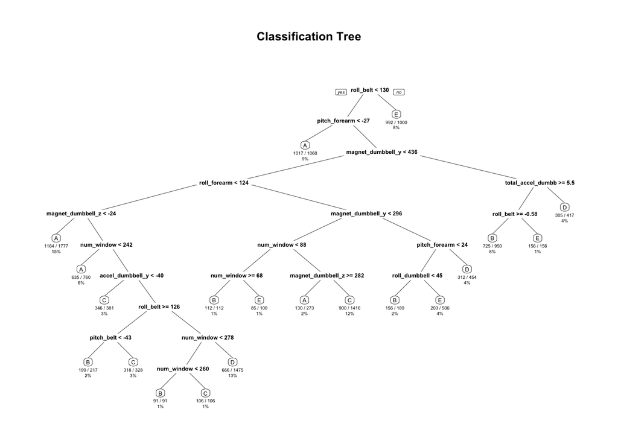

```r
model_DT <- rpart(classe ~ ., data=reduced_set, method="class")
pred_DT <- predict(model_DT, reduced_set, type = "class")
rpart.plot(model_DT, main="Classification Tree", extra=102, under=TRUE, faclen=0)
```

```r
confusionMatrix(pred_DT, reduced_set$classe)
```

```
## Confusion Matrix and Statistics
##
##           Reference
## Prediction    A    B    C    D    E
##          A 2946  461   48  222  193
##          B   57 1283   72   49   98
##          C   19  110 1670  285  147
##          D  272  338  162 1283  291
##          E   54   87  102   91 1436
##
## Overall Statistics
##
##                Accuracy : 0.7318
##                  95% CI : (0.7237, 0.7398)
##     No Information Rate : 0.2843
##     P-Value [Acc > NIR] : < 2.2e-16
##
##                   Kappa : 0.6595
##  Mcnemar's Test P-Value : < 2.2e-16
##
## Statistics by Class:
##
##                      Class: A Class: B Class: C Class: D Class: E
## Sensitivity            0.8799   0.5630   0.8130   0.6648   0.6633
## Specificity            0.8904   0.9709   0.9423   0.8920   0.9652
## Pos Pred Value         0.7612   0.8230   0.7485   0.5469   0.8113
## Neg Pred Value         0.9492   0.9025   0.9598   0.9314   0.9271
## Prevalence             0.2843   0.1935   0.1744   0.1639   0.1838
## Detection Rate         0.2502   0.1090   0.1418   0.1090   0.1219
## Detection Prevalence   0.3286   0.1324   0.1895   0.1992   0.1503
## Balanced Accuracy      0.8851   0.7670   0.8777   0.7784   0.8143
```

```r
model_RF <- randomForest(classe ~., data=reduced_set, type="class")       # Random Forest model
pred_RF <- predict(model_RF,reduced_set, type="class")

# Accuracy, error rates, in sample error
confusionMatrix(pred_RF, reduced_set$classe)
```

```
## Confusion Matrix and Statistics
##
##           Reference
## Prediction    A    B    C    D    E
##          A 3348    0    0    0    0
##          B    0 2279    0    0    0
##          C    0    0 2054    0    0
##          D    0    0    0 1930    0
##          E    0    0    0    0 2165
##
## Overall Statistics
##
##                Accuracy : 1
##                  95% CI : (0.9997, 1)
##     No Information Rate : 0.2843
##     P-Value [Acc > NIR] : < 2.2e-16
##
##                   Kappa : 1
##  Mcnemar's Test P-Value : NA
##
## Statistics by Class:
##
##                      Class: A Class: B Class: C Class: D Class: E
## Sensitivity            1.0000   1.0000   1.0000   1.0000   1.0000
## Specificity            1.0000   1.0000   1.0000   1.0000   1.0000
## Pos Pred Value         1.0000   1.0000   1.0000   1.0000   1.0000
## Neg Pred Value         1.0000   1.0000   1.0000   1.0000   1.0000
## Prevalence             0.2843   0.1935   0.1744   0.1639   0.1838
## Detection Rate         0.2843   0.1935   0.1744   0.1639   0.1838
## Detection Prevalence   0.2843   0.1935   0.1744   0.1639   0.1838
## Balanced Accuracy      1.0000   1.0000   1.0000   1.0000   1.0000
```

```r
# Accuracy clearly higher here, so going with RF.
```

The in-sample error is very low (the prediction is perfect), so I expect that the out-of-sample error to be low as well (less than 1%). The accuracy is clearly superior, so I will use random forest for predictions using the test data downloaded. To get an idea of the out-of-sample error, I use the test data from the 60/40 partition of the training data set:

```r
# Out of sample error with random forest
classe_col_number <- grep("classe",names(testData))             #This is the column that is the one we want to predict
predTest <- predict(model_RF, newdata = testData[,-classe_col_number], type="class")
confusionMatrix(predTest,testData$classe)$table
```

```
##           Reference
## Prediction    A    B    C    D    E
##          A 2232    3    0    0    0
##          B    0 1514    5    0    0
##          C    0    1 1362   12    0
##          D    0    0    1 1274    1
##          E    0    0    0    0 1441
```

```r
# We expect the out-of-sample error to be much less than 1% (0.3%).
```

The out-of-sample error is approximately 0.3%, less than 1% (calculated from the confusion matrix).

I now use this random forest model to make predictions using the test data set:

```r
predict_final <- predict(model_RF,newdata=TestD,type="class")
summary(predict_final)
```

```
## A B C D E
## 7 8 1 1 3
```

I also write out each of the predictions to a text file, as stipulated fors submission.

```r
# Write files for submission
pml_write_files = function(x){
  n = length(x)
  for(i in 1:n){
    filename = paste0("problem_id_",i,".txt")
    write.table(x[i],file=filename,quote=FALSE,row.names=FALSE,col.names=FALSE)
  }
}

pml_write_files(predict_final)
```